# Assignment 2

Harrison Deng

2024-03-12

```r
library("GEOquery")
library("knitr")
library("edgeR")
library("stringr")
library("limma")
library("ggplot2")
library("ComplexHeatmap")
library("gprofiler2")
library("circlize")
library("data.table")
```

Loading environment from assignment 1. We will use the `knitr` package to do so (Xie 2023). By doing so, we will inherently include all packages used in assignment 1. Refer to assignment 1 for references on those packages.

```r
if (basename(getwd()) == "Homework") {
  setwd("./Assignment 2")
}
preprocessed_workspace_path <- "preprocessed_workspace.RData"
if (exists("n_ctrl_vs_art")) {
  # Then continue
} else if (file.exists(preprocessed_workspace_path)) {
  print("Loaded from file cache.")
  load(preprocessed_workspace_path)
} else {
  part_a1_dir <- file.path(dirname(getwd()), "Assignment 1")
  part_a1_filename <- "a1_deng_yunyang.Rmd"
  part_a1_out <- "a1_deng_yunyang.nb.html"

  knit(file.path(part_a1_dir, part_a1_filename),
       output = file.path(getwd(), part_a1_out))
  save.image(preprocessed_workspace_path)
}
```

```
## [1] "Loaded from file cache."
```

# Summary

## Data set

The gene expression analysis will be performed on the normalized dataset generated in the previous assignment (#1). Aforementioned data set was procured from the Gene Expression Omnibus (GEO) with GSE196549. The dataset contains a variety of categories to stratify upon and categorize for testing. The variables used in the previous assignment and the variables we will continue to use in this assignment are the phenotype categories which designates if the patient sample is from a patient who has undergone antiretroviral therapy (ART), is an elite controller with no signs of viremia (EC), or a viremic controller with very low signs of viremia (VC). More specifically, there were $6$ patient samples, $18$ and $24$ respectively.

## Data set Pre-processing

The dataset was pre-processed via filtering out genes based on patient sample counts where the sum of counts per million (CPM) over patient samples must have been greater than $30$.

Duplicate rows with exact same values were simply and trivially deleted from the dataset. This reduced the number of genes (rows) by $14$.

The same dataset was than normalized via trimmed mean of m-values (TMM). TMM was used as we expect that most genes would not be differentially expressed. Furthermore, with TMM, we hoped to reduce technical variation as the process of recording gene expression is very complex with many steps that may introduce such variation.

## Preliminary Analysis

The resulting data was pre-emptively analysed at this stage via multidimensional scaling plots (MDS). The produced plot generated 3 groupings where one group was entirely VCs, another was primarily EC and VC, and the last was a mixture of EC, and ART patients.

A dispersion analysis via biological coefficient of variation (BCV) indicated that the produced pre-processed dataset shows that as gene expression increases, the biological coefficient of variation decreases approximately after $3\log CPM$. This result was validated by plotting the mean variance and seeing that the data largely follows the negative binomial distribution.

# Gene Expression Differential Analysis

> 1. Calculate p-values for each of the genes in your expression set. How many genes were significantly differentially expressed? What thresholds did you use and why?

Let’s review the data we have currently from assignment 1 (filtered and normalized).

```r
kable(
  n_ctrl_vs_art[1:5, 1:4],
  type = "html",
  caption = "Sample of Pre-processed Gene Expression Data Format"
)
```

Sample of Pre-processed Gene Expression Data Format

|  | R1015.S0031 | R1015.S0032 | R1015.S0033 | R1015.S0034 |
| --- | --- | --- | --- | --- |
| ENSG00000000419_DPM1 | 46.449060 | 92.701302 | 57.07520 | 45.465551 |
| ENSG00000000457_SCYL3 | 46.587514 | 42.621890 | 80.76557 | 57.971580 |
| ENSG00000000460_C1orf112 | 4.161062 | 5.814951 | 13.25336 | 3.785536 |
| ENSG00000000938_FGR | 125.177238 | 97.289294 | 72.30957 | 105.228717 |
| ENSG00000001036_FUCA2 | 11.910015 | 5.406567 | 20.76180 | 15.927311 |

```r
t(art_v_ec_meta[1, ])
```

```
##                              [,1]
## Sample_Name                  "R1015.S0031"
## Title                        "ART Patient 310817 Source LN 1"
## Patient                      "310817"
## Phenotype                    "ART"
## Source                       "LN"
## Replicate                    "1"
## Batch                        "1015"
## Sample_Well                  "A01"
## Cell_Number                  "500"
## Response                     "B*44 Gag AW11"
## Tetramer_Freq                "0.2"
## Age                          "55"
## Sex                          "Male"
## Race                         "White"
## Viral_Load                   "<20"
## CD4_Count                    "775"
## Sample_Years_Since_Diagnosis "35"
## UnalignableReads             "5271449"
## AlignableReads               "7606355"
## TotalReads                   "12877804"
## UniqueAlignReads             "5240615"
## MultipleMapReads             "2365740"
## MultiLocReads                "6108793"
## TotalAlign                   "38159750"
## AlignRate                    "0.5906562"
## UGPS                         "17194"
## GenesExpCountGRE1            "16937"
## FileName.R1                  "R1015.S0031_R1_001.fastq.gz"
## FileName.R2                  "R1015.S0031_R2_001.fastq.gz"
## pctGC.R1                     "47"
## pctGC.R2                     "47"
## Sample_Name_Orig             "310817_L1"
```

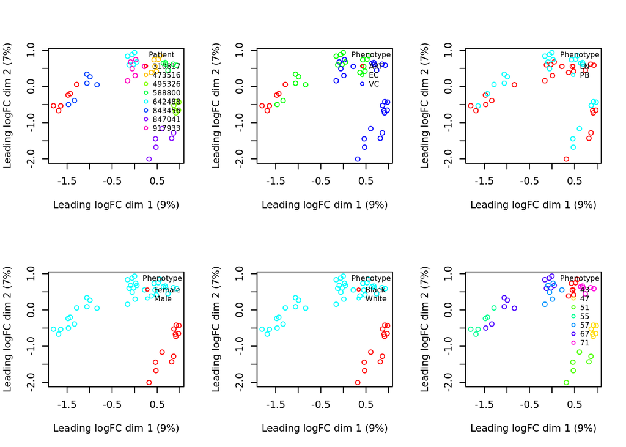

```r
phenotype_dge_mds_by <- function(classification_var, title, dge) {
  class_factors <- factor(classification_var)
  col <- c(rainbow(length(unique(classification_var))))
  class_col <- col[class_factors]

  limma::plotMDS(dge, labels = NULL, pch = 1, col = class_col)

  legend("topright", legend = levels(class_factors),
         pch = c(1), col = col, title = title,
         bty = "n", cex = 0.75)

}

par(mfrow = c(2, 3))
phenotype_dge_mds_by(art_v_ec_meta$Patient, "Patient", phenotype_dge)
phenotype_dge_mds_by(art_v_ec_meta$Phenotype, "Phenotype", phenotype_dge)
phenotype_dge_mds_by(art_v_ec_meta$Source, "Phenotype", phenotype_dge)
phenotype_dge_mds_by(art_v_ec_meta$Sex, "Phenotype", phenotype_dge)
phenotype_dge_mds_by(art_v_ec_meta$Race, "Phenotype", phenotype_dge)
phenotype_dge_mds_by(art_v_ec_meta$Age, "Phenotype", phenotype_dge)
```

```r
par(mfrow = c(1, 1))
```

Immediately, it is apparent that the sex, race, age and phenotype seem to have some influence on the genetic expression. To elaborate, the clustering when colouring based on sex and race show to very apparent groups. Furthermore, samples from similar patients are clearly similar Lastly, the clustering on the phenotype also seems rather distinct and forms interesting intersections with each other. Since we are interested in the associations between gene expression and phenotypic outcome, that is to say, we are interested in how gene expressions may be linked to HIV severity outcome, we will elect to look at the phenotype category more. Additionally, since single patients have multiple samples that are also relatively clustered together, we’ll look at those.

All figures above were generated via use of the `limma` package (Ritchie et al. 2015).

> 2. Multiple hypothesis testing - correct your p-values using a multiple hypothesis correction method. Which method did you use? And Why? How many genes passed correction?

Throughout the gene expression analysis and specifically, the fitting and testing of the genewise negative binomial generalized linear models, `EdgeR` functions will be used (Chen et al. 2024).

We will begin by creating design pattern matrix for the model and fitting the expression matrix to the design pattern.

```r
model_design_pat <- model.matrix(~ art_v_ec_meta$Patient + art_v_ec_meta$Phenotype)

model_design_pat[1:5,]
```

```
##   (Intercept) art_v_ec_meta$Patient art_v_ec_meta$PhenotypeEC
## 1           1                310817                         0
## 2           1                310817                         0
## 3           1                310817                         0
## 4           1                310817                         0
## 5           1                310817                         0
##   art_v_ec_meta$PhenotypeVC
## 1                         0
## 2                         0
## 3                         0
## 4                         0
## 5                         0
```

```r
fit_phenotype_glmQL <- glmQLFit(phenotype_dge, model_design_pat)
```

Specifically, the reference category will be the ART samples while we will test the elite controllers.

```r
coefficent_col <- "art_v_ec_meta$PhenotypeEC"

qlf.ARTvsEC  <- glmQLFTest(fit_phenotype_glmQL, coef = coefficent_col)

qlf_art_vs_ec_results <- topTags(qlf.ARTvsEC, sort.by = "PValue",
                           n = nrow(n_ctrl_vs_art))$table
qlf_art_vs_ec_results$logFDR <- -log2(qlf_art_vs_ec_results$FDR)

kable(
  qlf_art_vs_ec_results[1:10,],
  row.names = TRUE,
  type = "html",
  caption = "Top 10 Significant Gene Expr. Change In Elite Controllers"
)
```

Top 10 Significant Gene Expr. Change In Elite Controllers

|  | logFC | logCPM | F | PValue | FDR | logFDR |
| --- | --- | --- | --- | --- | --- | --- |
| ENSG00000204632_HLA-G | 2.741310 | 5.871064 | 158.99632 | 0 | 0e+00 | 40.68422 |
| ENSG00000050165_DKK3 | 8.272533 | 7.517647 | 117.73608 | 0 | 0e+00 | 33.77999 |
| ENSG00000242086_LINC00969 | -1.836273 | 6.335703 | 114.97722 | 0 | 0e+00 | 33.76792 |
| ENSG00000206341_HLA-H | 1.536344 | 8.275920 | 105.99672 | 0 | 0e+00 | 32.16677 |
| ENSG00000185829_ARL17A | -1.620538 | 5.811832 | 91.01413 | 0 | 0e+00 | 28.84639 |
| ENSG00000213402_PTPRCAP | 1.266490 | 10.141608 | 89.53733 | 0 | 0e+00 | 28.72925 |
| ENSG00000188404_SELL | -2.769353 | 7.262893 | 70.20848 | 0 | 1e-07 | 23.55747 |
| ENSG00000171222_SCAND1 | 1.267721 | 6.752457 | 69.32223 | 0 | 1e-07 | 23.48187 |
| ENSG00000152520_PAN3 | -1.424901 | 6.993914 | 65.79373 | 0 | 2e-07 | 22.56310 |
| ENSG00000165929_TC2N | -1.367007 | 7.411482 | 65.07856 | 0 | 2e-07 | 22.49028 |

### Summary of Results

```r
alpha <- 0.05
length(which(qlf_art_vs_ec_results$PValue < alpha))
```

```
## [1] 3122
```

Furthermore, the following demonstrates the amount passing multiple tests correction as follows.

```r
length(which(qlf_art_vs_ec_results$FDR < alpha))
```

```
## [1] 1400
```

The built in false discovery rate (FDR) multiple testing correction of `glmQLFTest` was chosen as it offers less false negatives compared to Bonferonni Corrections.

> 3. Show the amount of differentially expressed genes using an MA Plot or a Volcano plot. Highlight genes of interest.

We will generate a volcano plot to visualize and further discuss our results.

[figure not shown]

```r
# Create a basic volcano plot

signif_expr <- 0.25

qlf_art_vs_ec_results$regulation <- apply(
  qlf_art_vs_ec_results[c("FDR", "logFC")],
  MARGIN = 1,
  FUN = function(v) {
    if (v["FDR"] < alpha) {
      if (v["logFC"] >= signif_expr) {
        return("Upregulated")
      } else if (v["logFC"] <= -signif_expr) {
        return("Downregulated")
      }
    }
    return("Insignificant Change")
})

ggplot(
       qlf_art_vs_ec_results,
       aes(x = logFC, y = logFDR, color = regulation)) +
  geom_point(alpha = 0.4) +
  scale_color_manual(
                     values = c("blue", "grey", "red")) +
  theme_bw() +
  xlab("Log2 Fold Change") +
  ylab("-Log10 Adjusted P-Value") +
  geom_vline(xintercept = c(-signif_expr, signif_expr), linetype = "dotted") +
  geom_hline(yintercept = -log2(alpha), linetype = "dotted") +
  ggtitle("Expression and Association Levels of Genes")
```

The top right indicate the upregulated genes and the top left indicate the downregulated genes. We see that there are many genes that were not significant after FDR P-value adjustments.

> 4. Visualize your top hits using a heatmap. Do you conditions cluster  
>    together? Explain why or why not.

Our next step will be to plot a heatmap. This heatmap will be a re-scaled heatmap of only the significantly associated genes after FDR.

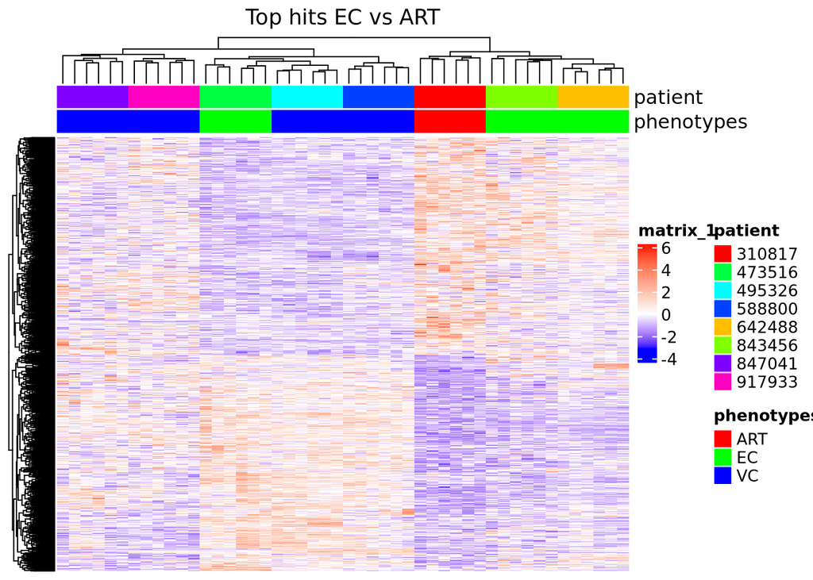

```r
unique_patient <- unique(art_v_ec_meta$Patient)
unique_patientcolors <- rainbow(n = length(unique_patient))
names(unique_patientcolors) <- unique_patient

unique_phenotypes <- unique(art_v_ec_meta$Phenotype)
unique_phenotypescolors <- rainbow(n = length(unique_phenotypes))
names(unique_phenotypescolors) <- unique_phenotypes

ha_pat <- HeatmapAnnotation(df = data.frame(
  patient = art_v_ec_meta$Patient,
  phenotypes = art_v_ec_meta$Phenotype),
  col = list(
      patient = unique_patientcolors,
      phenotypes = unique_phenotypescolors
    ),
  show_legend = TRUE
)

top_hits <- row.names(qlf_art_vs_ec_results)[qlf_art_vs_ec_results$FDR < alpha]
gene_names <- row.names(n_ctrl_vs_art)
art_v_ec_sig_norm <- t(scale(t(n_ctrl_vs_art[gene_names %in% top_hits,])))
if (min(art_v_ec_sig_norm) == 0) {
  heatmap_col <- colorRamp2(c(0, max(art_v_ec_sig_norm)), c("white", "red"))
} else {
  heatmap_col <- colorRamp2(c(min(art_v_ec_sig_norm), 0,
  max(art_v_ec_sig_norm)),
  c("blue", "white", "red"))
}

current_heatmap <- Heatmap(as.matrix(art_v_ec_sig_norm),
  top_annotation = ha_pat,
  cluster_rows = TRUE,
  cluster_columns = TRUE,
  show_row_dend = TRUE,
  show_column_dend = TRUE,
  col = heatmap_col,
  show_column_names = FALSE,
  show_row_names = FALSE,
  show_heatmap_legend = TRUE,
  column_title = ("Top hits EC vs ART")
)

current_heatmap
```

The above heatmap demonstrates how the different genes perform in association with different HIV outcomes. Immediately, the figure depicts very obvious clustering of genetic expression level changes in the column of patient $310817$ and antiretroviral therapy patients patients (ARTs). Specifically, we can see very significant clustering of upregulation occurring in genes placed in the upper half of the square, while genes in the lower have are very significantly downregulated. Generally speaking however, there is significant downregulation in the same set of genes that was previously described as upregulated in viremic controller patients (VCs). Elite controllers (ECs) seem to also have a tad more downregulated genes in the upper half set of genes however, still closer to the previously mentioned $310817$ ART than the general VC set of patients and genes. This corroborates the results seen by the MDS plots where we have some intersections between the different phenotypes.

This heatmap was generated with use of the library `ComplexHeatmap` (Gu 2022).

> Make sure all your figures have proper heading and labels. Every figure  
> included in the report should have a detailed figure legend.

# Threshold Overrepresentation Analysis

This section will answer the following questions as described by the outline for assignment 2. Please see the end of this section for the answer to these questions.

> 1. Which method did you choose and why?

```r
#where to put all the generated files
working_dir <- "./g_profiler/generated_data"
if (!dir.exists(working_dir)) {
  dir.create(working_dir, recursive = TRUE)
}


# where to find the data files needed to run the analysis
data_dir <-  "./g_profiler/data"
if (!dir.exists(data_dir)) {
  dir.create(data_dir, recursive = TRUE)
}


# default min size of the genesets for example -  3
min_gs_size <- 3

#min intersection between your genelist and the geneset - for example 3
min_intersection <- 3

# organism parameter used for g:profiler.
# First letter of first word in species name followed by
# the second word for example - hsapiens
organism <- "hsapiens"

sources <- c("REAC", "WP", "GO:BP")
max_term_size <- 250
```

IDs will be used from the given dataset and parsed with help from the `stringr` library (Wickham 2023).

```r
qlf_art_vs_ec_results$hgnc_symbol <- lapply(row.names(qlf_art_vs_ec_results), FUN = function(x) {
  return(unlist(str_split(x, "_"))[[2]])
})

regulated_genes_dir <- "regulated_genes"

if (!dir.exists("regulated_genes")) {
  dir.create(regulated_genes_dir)
}

upregulated_genes <- qlf_art_vs_ec_results$hgnc_symbol[
  which(qlf_art_vs_ec_results$PValue < 0.05
  & qlf_art_vs_ec_results$logFC > 0)]
downregulated_genes <- qlf_art_vs_ec_results$hgnc_symbol[
  which(qlf_art_vs_ec_results$PValue < 0.05
  & qlf_art_vs_ec_results$logFC < 0)]
write.table(x=upregulated_genes,
  file=file.path(getwd(), file.path(
    regulated_genes_dir,
    "upregulated_genes.txt")),
  sep = "\n",row.names = FALSE,
  col.names = FALSE,quote = FALSE)
write.table(x=downregulated_genes,
  file=file.path(getwd(), file.path(
    regulated_genes_dir,
    "downregulated_genes.txt")),
sep = "\n",row.names = FALSE,
col.names = FALSE,quote = FALSE)
```

The next steps involve running g:Profiler programmatically via R. We will try to cache the results when possible with use of the `data.table` library (Barrett et al. 2024).

```r
query_gprofiler <- function(
    genes,
    cache_name = "") {

  cache_path <- file.path(working_dir, "results", cache_name)
  if (!dir.exists(dirname(cache_path)) && cache_name != "") {
    dir.create(dirname(cache_path))
  }
  if (file.exists(cache_path) && cache_name != "") {
    enrichment_results <- fread(cache_path)
  } else {
gp_results <- gost(query = unlist(genes),
                       significant = FALSE,
                       ordered_query = FALSE,
                       exclude_iea = TRUE,
                       evcodes = TRUE,
                       correction_method = "fdr",
                       organism = organism,
                       domain_scope = "annotated",
                       source = sources)
    enrichment_results <- gp_results$result
    if (cache_name != "") {
      fwrite(enrichment_results, file = cache_path)
    }
  }

  return(enrichment_results)
}

upregulated_enrichment <- query_gprofiler(
  upregulated_genes,
  "upregulation_results.csv")

downregulated_enrichment <- query_gprofiler(
  downregulated_genes,
  "downregulation_results.csv")

all_enrichment <- query_gprofiler(
  c(upregulated_genes, downregulated_genes),
  "all_results.csv")
```

Briefly, configure to only show specific, relevent columns and maximum number of results.

```r
important_columns <- c(
  "term_name",
  "p_value",
  "term_size",
  "intersection_size",
  "source"
)

number_of_results <- 15
```

> 2. What annotation data did you use and why? What version of the annotation are you using?

For this assignment, I used REAC, WP, GO:BP as described outlined in the tutorial. I used the latest version of the annotations which can be see in the following code block.

```r
str(get_version_info(organism = organism))
```

```
## List of 8
##  $ biomart          : chr "Ensembl"
##  $ biomart_version  : chr "111"
##  $ display_name     : chr "Human"
##  $ genebuild        : chr "GRCh38.p14"
##  $ gprofiler_version: chr "e111_eg58_p18_30541362"
##  $ organism         : chr "hsapiens"
##  $ sources          :List of 11
##   ..$ CORUM:List of 2
##   .. ..$ name   : chr "CORUM protein complexes"
##   .. ..$ version: chr "28.11.2022 Corum 4.1"
##   ..$ GO:BP:List of 2
##   .. ..$ name   : chr "biological process"
##   .. ..$ version: chr "annotations: BioMart\nclasses: releases/2024-01-17"
##   ..$ GO:CC:List of 2
##   .. ..$ name   : chr "cellular component"
##   .. ..$ version: chr "annotations: BioMart\nclasses: releases/2024-01-17"
##   ..$ GO:MF:List of 2
##   .. ..$ name   : chr "molecular function"
##   .. ..$ version: chr "annotations: BioMart\nclasses: releases/2024-01-17"
##   ..$ HP   :List of 2
##   .. ..$ name   : chr "Human Phenotype Ontology"
##   .. ..$ version: chr "annotations: 01.2024\nclasses: None"
##   ..$ HPA  :List of 2
##   .. ..$ name   : chr "Human Protein Atlas"
##   .. ..$ version: chr "annotations: HPA website: 23-07-17\nclasses: script: 24-01-02"
##   ..$ KEGG :List of 2
##   .. ..$ name   : chr "Kyoto Encyclopedia of Genes and Genomes"
##   .. ..$ version: chr "KEGG FTP Release 2024-01-22"
##   ..$ MIRNA:List of 2
##   .. ..$ name   : chr "miRTarBase"
##   .. ..$ version: chr "Release 9.0"
##   ..$ REAC :List of 2
##   .. ..$ name   : chr "Reactome"
##   .. ..$ version: chr "annotations: BioMart\nclasses: 2024-1-25"
##   ..$ TF   :List of 2
##   .. ..$ name   : chr "Transfac"
##   .. ..$ version: chr "annotations: TRANSFAC Release 2023.2\nclasses: v2"
##   ..$ WP   :List of 2
##   .. ..$ name   : chr "WikiPathways"
##   .. ..$ version: chr "20240101"
##  $ taxonomy_id      : chr "9606"
```

> 3. How many genesets were returned with what thresholds?

All term sizes were capped at 250 and adjusted p-values were capped at 0.05. The max term size was chosen to reduce highly broad-covering pathways. The alpha value choice was previously described.

Upregulated significant genes enrichment analysis as follows.

```r
thresholded_up <- upregulated_enrichment[
  upregulated_enrichment$term_size <= max_term_size &
  upregulated_enrichment$p_value < alpha,]
ordered_thresholded_up <- thresholded_up[
  order(thresholded_up$intersection_size),]
kable(
  thresholded_up[1:number_of_results, ..important_columns],
  type = "html",
  caption = paste(
    "Top",
    number_of_results,
    "Pathways Enriched with Up-regulated Genes"
  )
)
```

Top 15 Pathways Enriched with Up-regulated Genes

| term_name | p_value | term_size | intersection_size | source |
| --- | --- | --- | --- | --- |
| regulation of T cell differentiation | 0.0000003 | 127 | 31 | GO:BP |
| regulation of lymphocyte differentiation | 0.0000010 | 150 | 33 | GO:BP |
| T cell differentiation | 0.0000015 | 201 | 39 | GO:BP |
| regulation of leukocyte differentiation | 0.0000222 | 225 | 39 | GO:BP |
| positive regulation of lymphocyte activation | 0.0000295 | 246 | 41 | GO:BP |
| viral life cycle | 0.0000522 | 243 | 40 | GO:BP |
| regulation of viral process | 0.0000757 | 160 | 30 | GO:BP |
| regulation of viral life cycle | 0.0001068 | 138 | 27 | GO:BP |
| positive regulation of T cell activation | 0.0001639 | 193 | 33 | GO:BP |
| positive regulation of leukocyte cell-cell adhesion | 0.0001937 | 213 | 35 | GO:BP |
| T cell receptor signaling pathway | 0.0003195 | 114 | 23 | GO:BP |
| positive regulation of T cell differentiation | 0.0003633 | 84 | 19 | GO:BP |
| protein dephosphorylation | 0.0005061 | 169 | 29 | GO:BP |
| positive regulation of hemopoiesis | 0.0005799 | 136 | 25 | GO:BP |
| positive regulation of leukocyte differentiation | 0.0005799 | 136 | 25 | GO:BP |

Downregulated significant genes enrichment analysis as follows.

```r
thresholded_down <- downregulated_enrichment[
  downregulated_enrichment$term_size <= max_term_size &
  downregulated_enrichment$p_value < alpha,]
ordered_thresholded_down <- thresholded_down[
  order(thresholded_down$intersection_size),]
kable(
  thresholded_down[1:number_of_results, ..important_columns],
  type = "html",
  caption = paste(
    "Top",
    number_of_results,
    "Pathways Enriched with Down-regulated Genes"
  )
)
```

Top 15 Pathways Enriched with Down-regulated Genes

| term_name | p_value | term_size | intersection_size | source |
| --- | --- | --- | --- | --- |
| cytoplasmic translation | 0.0000001 | 154 | 36 | GO:BP |
| regulation of telomere maintenance | 0.0000006 | 103 | 27 | GO:BP |
| translational initiation | 0.0000010 | 113 | 28 | GO:BP |
| positive regulation of chromosome organization | 0.0000018 | 109 | 27 | GO:BP |
| protein-RNA complex organization | 0.0000034 | 204 | 39 | GO:BP |
| telomere maintenance | 0.0000047 | 151 | 32 | GO:BP |
| mRNA catabolic process | 0.0000077 | 227 | 41 | GO:BP |
| nuclear-transcribed mRNA catabolic process | 0.0000126 | 120 | 27 | GO:BP |
| protein-RNA complex assembly | 0.0000211 | 194 | 36 | GO:BP |
| regulation of chromosome organization | 0.0000321 | 240 | 41 | GO:BP |
| regulation of RNA splicing | 0.0000904 | 173 | 32 | GO:BP |
| regulation of mRNA processing | 0.0001000 | 118 | 25 | GO:BP |
| positive regulation of telomere maintenance | 0.0001267 | 69 | 18 | GO:BP |
| telomere organization | 0.0002325 | 181 | 32 | GO:BP |
| mitotic sister chromatid cohesion | 0.0002332 | 29 | 11 | GO:BP |

All significant genes enrichment analysis as follows.

```r
thresholded_all <- all_enrichment[
  all_enrichment$term_size <= max_term_size &
  all_enrichment$p_value < alpha,]
ordered_thresholded_all <- thresholded_all[
  order(thresholded_all$intersection_size),]

kable(
  thresholded_all[1:number_of_results, ..important_columns],
  type = "html",
  caption = paste(
    "Top",
    number_of_results,
    "Pathways Enriched with All Regulated Genes"
  )
)
```

Top 15 Pathways Enriched with All Regulated Genes

| term_name | p_value | term_size | intersection_size | source |
| --- | --- | --- | --- | --- |
| protein-RNA complex organization | 0.00e+00 | 204 | 66 | GO:BP |
| protein-RNA complex assembly | 1.00e-07 | 194 | 61 | GO:BP |
| cytoplasmic translation | 4.00e-07 | 154 | 51 | GO:BP |
| mitochondrial ATP synthesis coupled electron transport | 1.70e-06 | 88 | 34 | GO:BP |
| ATP synthesis coupled electron transport | 1.70e-06 | 88 | 34 | GO:BP |
| aerobic electron transport chain | 3.10e-06 | 82 | 32 | GO:BP |
| import into nucleus | 8.30e-06 | 119 | 40 | GO:BP |
| regulation of telomere maintenance | 1.15e-05 | 103 | 36 | GO:BP |
| respiratory electron transport chain | 1.20e-05 | 99 | 35 | GO:BP |
| intrinsic apoptotic signaling pathway by p53 class mediator | 1.25e-05 | 59 | 25 | GO:BP |
| translational initiation | 1.50e-05 | 113 | 38 | GO:BP |
| positive regulation of chromosome organization | 1.61e-05 | 109 | 37 | GO:BP |
| regulation of T cell differentiation | 1.71e-05 | 127 | 41 | GO:BP |
| regulation of lymphocyte differentiation | 1.78e-05 | 150 | 46 | GO:BP |
| protein import into nucleus | 1.80e-05 | 114 | 38 | GO:BP |

> 4. Run the analysis using the up-regulated set of genes, and the down-regulated set of genes separately. How do these results compare to using the whole list (i.e all differentially expressed genes together vs. the up-regulated and down regulated differentially expressed genes separately)?

In the union set of both up and down regulated genes, we see that there are many more results. This is due to there being more potential genes to partake in various pathways than any individual. Furthermore, for the same reason, there are many more results where the range of possible intersection sizes is increased and the relative number of larger term sizes may also be increased.

> Additional Notes: Present your results with the use of tables and screenshots. All figures should have appropriate figure legends.

> If using figures create a figures directory in your repo and make sure all references to the figures are relative in your Rmarkdown notebook.

# Interpretation

The assignment outline requires the following.

> 1. Do the over-representation results support conclusions or mechanism discussed in the original paper?

Yes, the over-representation results support the general conclusions discussed in the original paper. To elaborate, the paper specifically discusses the increase of CD8+ T cells within germinal centers (Collins et al. 2023). This corresponds with the several up-regulation of positive regulation pathways of T-cells. This ranges from T-cell differentiation pathways to T-cell activation pathways.

> 2. Can you find evidence, i.e. publications, to support some of the results that you see. How does this evidence support your results.

Diving into the specifics, we can see there is an upregulation of various immune cell differentiation. This corroborates the general theory that the virus has some capacity to surpress the operations of the immune system (Deng et al. 2018).

In terms of down-regulation, several pathways associated with the lifecycle of a cell have very large intersections and highly significant p-values. This is also a known effect of HIV-1 and has been previously studied (Piekna-Przybylska and Maggirwar 2018). Furthermore, the results obtained seem to indicate various regulations in mRNA machinery are downregulated. This is also a well known effect with various papers citing as such (Toro-Ascuy et al. 2016; Wang et al. 2022).

# Additional Notes

- Throughout this notebook, `knitr` will be used for the displaying of tables (Xie 2023).
- Throughout this notebook, `ggplot2` will be used for the generation of figures (Wickham 2016).
- Coloring associated functions were largely obtained and used from the `circlize` library (Gu et al. 2014).

# References

Barrett, Tyson, Matt Dowle, Arun Srinivasan, Jan Gorecki, Michael Chirico, and Toby Hocking. 2024. *Data.table: Extension of ‘Data.frame‘*. Manual. https://CRAN.R-project.org/package=data.table.

Chen, Yunshun, Lizhong Chen, Aaron A. T. Lun, Pedro Baldoni, and Gordon K. Smyth. 2024. “edgeR 4.0: Powerful Differential Analysis of Sequencing Data with Expanded Functionality and Improved Support for Small Counts and Larger Datasets.” *bioRxiv*. https://doi.org/10.1101/2024.01.21.576131.

Collins, David R., Julia Hitschfel, Jonathan M. Urbach, Geetha H. Mylvaganam, Ngoc L. Ly, Umar Arshad, Zachary J. Racenet, Adrienne G. Yanez, Thomas J. Diefenbach, and Bruce D. Walker. 2023. “Cytolytic CD8+ T Cells Infiltrate Germinal Centers to Limit Ongoing HIV Replication in Spontaneous Controller Lymph Nodes.” *Science Immunology* 8 (83): eade5872. https://doi.org/10.1126/sciimmunol.ade5872.

Deng, Liyao, Qiurui Zeng, Mingshu Wang, Anchun Cheng, Renyong Jia, Shun Chen, Dekang Zhu, et al. 2018. “Suppression of NF-κB Activity: A Viral Immune Evasion Mechanism.” *Viruses* 10 (8, 8): 409. https://doi.org/10.3390/v10080409.

Gu, Zuguang. 2022. “Complex Heatmap Visualization.” *iMeta*. https://doi.org/10.1002/imt2.43.

Gu, Zuguang, Lei Gu, Roland Eils, Matthias Schlesner, and Benedikt Brors. 2014. “Circlize Implements and Enhances Circular Visualization in R.” *Bioinformatics (Oxford, England)* 30 (19): 2811–12.

Piekna-Przybylska, Dorota, and Sanjay B. Maggirwar. 2018. “CD4+ Memory T Cells Infected with Latent HIV-1 Are Susceptible to Drugs Targeting Telomeres.” *Cell Cycle (Georgetown, Tex.)* 17 (17): 2187–2203. https://doi.org/10.1080/15384101.2018.1520568.

Ritchie, Matthew E, Belinda Phipson, Di Wu, Yifang Hu, Charity W Law, Wei Shi, and Gordon K Smyth. 2015. “limma Powers Differential Expression Analyses for RNA-sequencing and Microarray Studies.” *Nucleic Acids Research* 43 (7): e47. https://doi.org/10.1093/nar/gkv007.

Toro-Ascuy, Daniela, Bárbara Rojas-Araya, Fernando Valiente-Echeverría, and Ricardo Soto-Rifo. 2016. “Interactions Between the HIV-1 Unspliced mRNA and Host mRNA Decay Machineries.” *Viruses* 8 (11, 11): 320. https://doi.org/10.3390/v8110320.

Wang, Shuqi, Huanxiang Li, Zhengxing Lian, and Shoulong Deng. 2022. “The Role of RNA Modification in HIV-1 Infection.” *International Journal of Molecular Sciences* 23 (14): 7571. https://doi.org/10.3390/ijms23147571.

Wickham, Hadley. 2016. *Ggplot2: Elegant Graphics for Data Analysis*. Springer-Verlag New York. https://ggplot2.tidyverse.org.

———. 2023. *Stringr: Simple, Consistent Wrappers for Common String Operations*. Manual. https://CRAN.R-project.org/package=stringr.

Xie, Yihui. 2023. *Knitr: A General-Purpose Package for Dynamic Report Generation in R*. https://yihui.org/knitr/.